# Course assignment 1

Jen Villwock

## Load and preprocessing the data

Downloaded data from github onto computer before reading it into r. Using the lubridate package, transformed the date variable into a date object.

```r
activity <- read.csv("C:\\Users\\Rob\\OneDrive\\Documents\\Stats lab\\activity.csv")

activity <- activity %>%
  mutate(date = ymd(date))
```

## Plots and analysis

First is a histogram of the total number of steps taken each day (excluding missing values). Created a day variable to to group steps data by. Created a steps_per_day variable by group_by day and them getting the sum for each day.

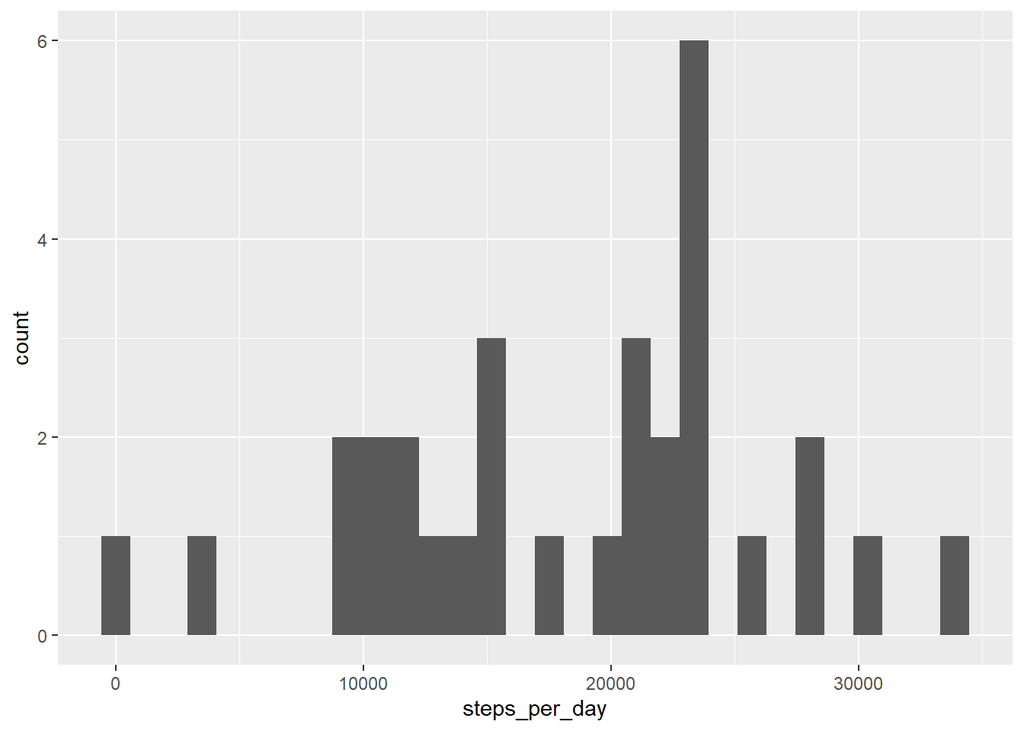

```r
step_hist <- activity %>%
  mutate(dayz = day(date)) %>%
  group_by(dayz) %>%
  summarise(steps_per_day = sum(steps, na.rm = TRUE)) %>%
  ggplot(aes(steps_per_day))

step_hist + geom_histogram(bins = 30)
```

## Average daily active pattern

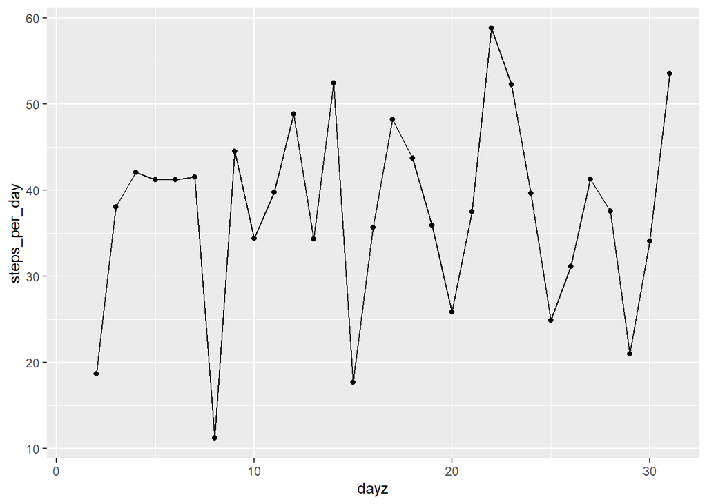

```r
activity %>%
  mutate(dayz = day(date)) %>%
  group_by(dayz) %>%
  summarise(steps_per_day = mean(steps, na.rm = TRUE)) %>%
  ungroup(.) %>%
  ggplot(aes(dayz, steps_per_day))+
  geom_point()+
  geom_line()
```

```r
result <- activity %>%
  group_by(interval) %>%
  summarise(steps_per_interval = mean(steps, na.rm = TRUE)) %>%
  filter(steps_per_interval == max(steps_per_interval))

result
```

```
## # A tibble: 1 × 2
##   interval steps_per_interval
##      <int>              <dbl>
## 1      835               206.
```

The 5 minute interval across all days with the most steps on average was interval 835 with 206 steps average.

## Imputing missing variables

```r
new_activity <- activity

new_activity$steps[is.na(new_activity$steps)] <- mean(new_activity$steps,na.rm = TRUE)
```

Comparing the old and new data sets.

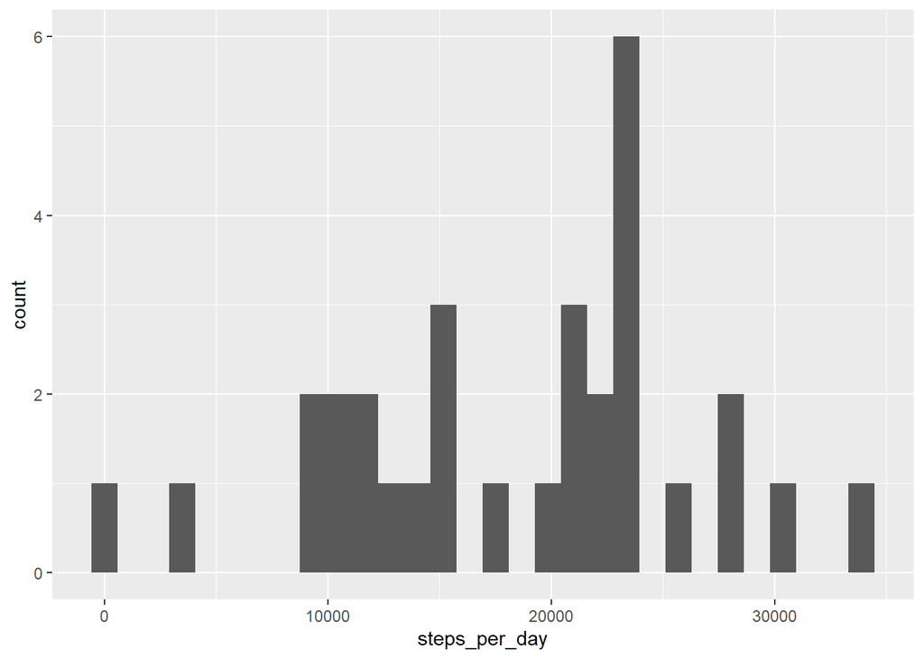

```r
step_hist <- activity %>%
  mutate(dayz = day(date)) %>%
  group_by(dayz) %>%
  summarise(steps_per_day = sum(steps, na.rm = TRUE)) %>%
  ggplot(aes(steps_per_day))

step_hist + geom_histogram(bins = 30)
```

```r
mean(step_hist$data$steps_per_day, na.rm = TRUE)
```

```
## [1] 18406.71
```

```r
median(step_hist$data$steps_per_day, na.rm = TRUE)
```

```
## [1] 20525
```

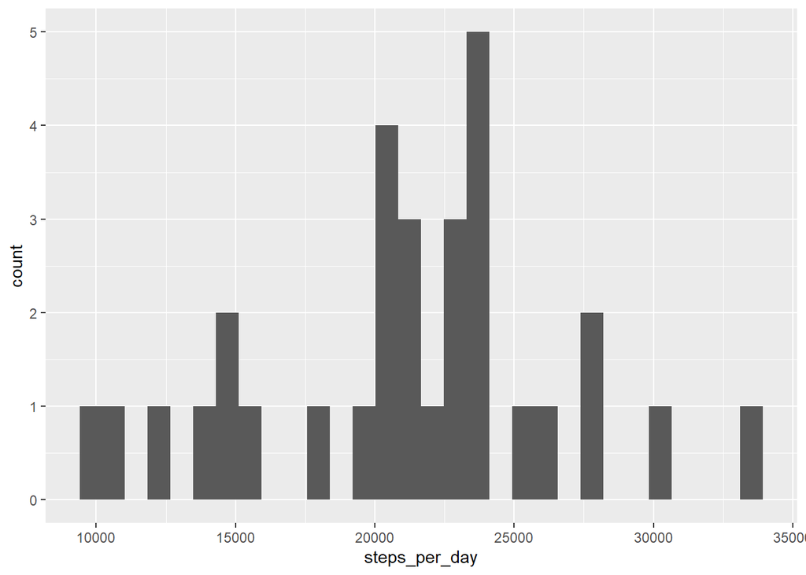

```r
# Imputed data set
new_step_hist <- new_activity %>%
  mutate(dayz = day(date)) %>%
  group_by(dayz) %>%
  summarise(steps_per_day = sum(steps, na.rm = TRUE)) %>%
  ggplot(aes(steps_per_day))

new_step_hist + geom_histogram(bins = 30)
```

```r
mean(new_step_hist$data$steps_per_day, na.rm = TRUE)
```

```
## [1] 21185.08
```

```r
median(new_step_hist$data$steps_per_day, na.rm = TRUE)
```

```
## [1] 21641
```

After imputing missing values, the key differences are that the average is slightly higher and the median is also sightly higher. Also in the imputed data set, the mean and median are closer than in the original data.

## Differences between weekdays and weekends

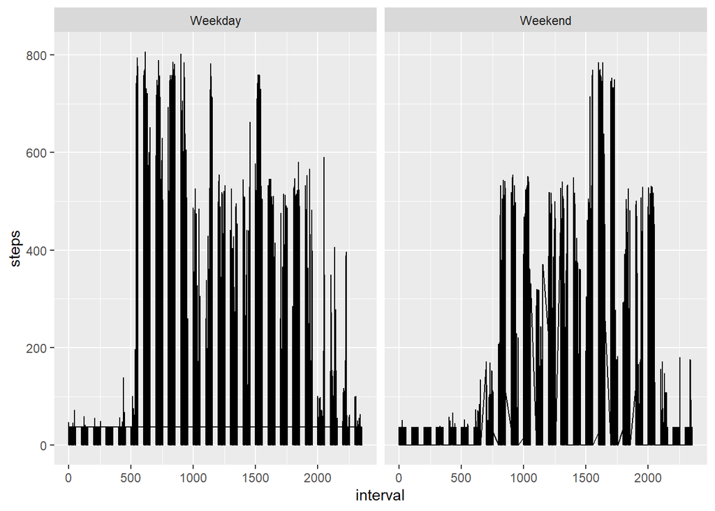

```r
new_activity %>%
  mutate(type_day = weekdays(date)) %>%
  mutate(type_day_2 = ifelse(type_day %in%  c("Saturday", "Sunday"), "Weekend", "Weekday")) %>%
  ggplot(aes(interval, steps))+
  geom_line()+
  facet_wrap(~type_day_2)
```